# Simulating clinical trials

### Updating the delay simulation–150 days of nothing.

Suppose that you are on day 150, and not a single patient has shown up. You were expecting the time to the first patient to be around day 131, but it looks like things might be far worse. What does the above average delay to the start of your study do to your estimate of the total sample size?

### Figure 6.10. Updated estimate of total sample size after 150 days of nothing.

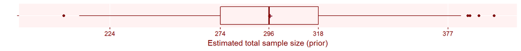

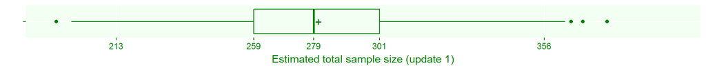

It looks like the delay has not hurt the trial that much so far.

### Figure 6.11. How much longer do you expect to wait after 150 days of nothing.

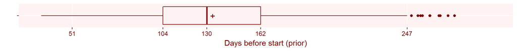

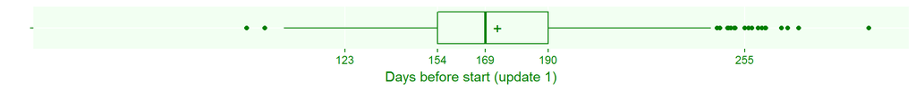

This boxplot shows when you think the trial will start, now that you know that the delay is at least 150 days. Notice that the model is placing a small probability on the possibility that the study actually started prior to 150 days, but nobody wanted to announce the start until some patients actually started showing up. You can easily modify this model to zero out the probability associated with start times earlier than 150 days.

The remaining parameters remain unchanged, of course.

### Figure 6.12. Update of delta2 after 150 days of nothing.

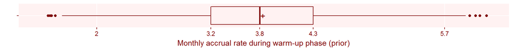

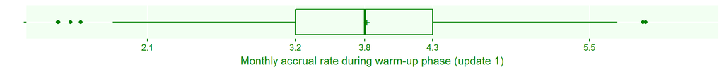

The slight differences you see here are just variations due to the simulation and the prior estimate of the accrual rate during the early phase and the updated estimate of the accrual rate during the early phase are identical if you don’t have any data yet in the early phase.

### Figure 6.13. Update of delta3 after 150 days of nothing.

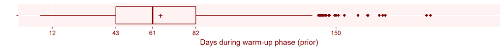

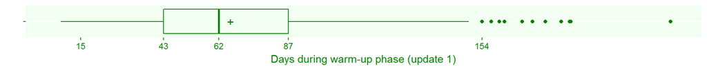

Similarly, the estimated duration of the early phase is unchanged if you haven’t even entered the early phase yet.

### Figure 6.14. Update of lambda after 150 days of nothing.

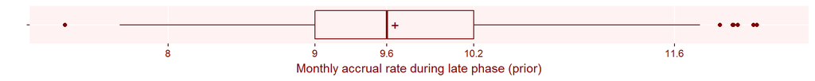

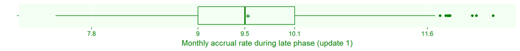

Finally, the estimated accrual rate during the late phase is unchanged. You have no data in the early or late phases, yet.

### Figure 6.15. Second update of total sample size.

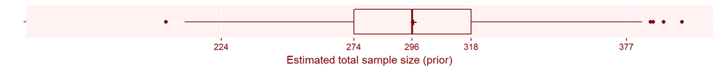

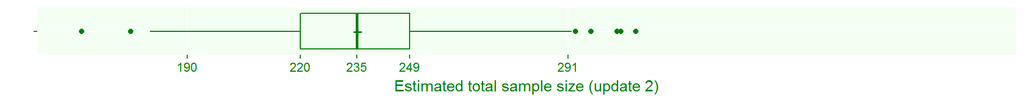

The news is very bad. What’s accounting for most of your shortfall?

### Figure 6.16. Second update of delta2.

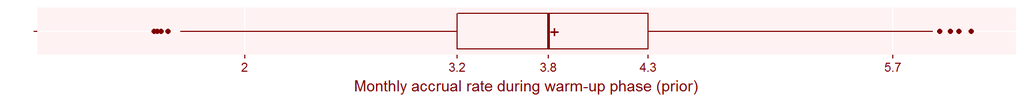

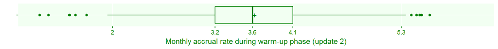

The rate of accrual during the early phase appears to be only slightly below what we thought it might be.

### Figure 6.17. Second update of delta3.

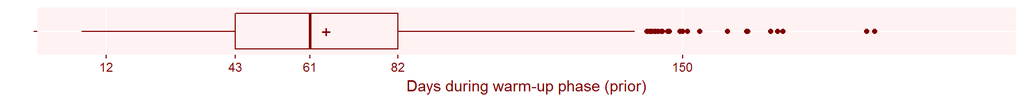

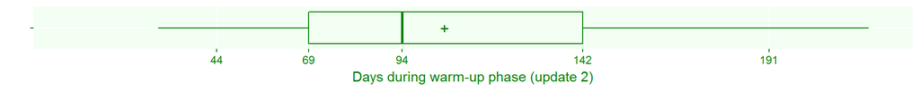

The duration of the early phase, however, appears to be substantially longer than we expected.

### Figure 6.18. Second update of lambda.

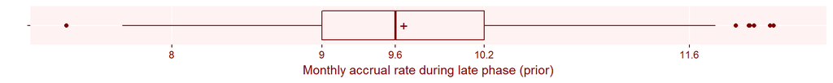

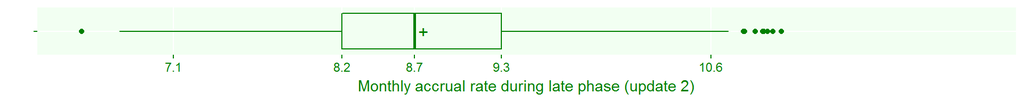

The accrual rate during the late phase seems to be a bit lower than we thought, but not by much. It looks like no one factor is totally to blame. The shortfall is affected by the longer than normal time to start the study, combined with the longer than normal duration of slow accrual combined with the slower than expected accrual rates both early and late.

### Part 7. Modeling exclusions and refusals

There’s a gauntlet that patients must travel through before they are officially part of your clinical trial. As you ask them questions, you will find that some of the patients might not meet all of your inclusion criteria. Also, the patients may change their minds, after hearing the details of your clinical trial, and decide that they don’t really want to participate after all.

You can model these two processes using binomial distributions.

Here’s some possible prior distributions for the proportion excluded and the proportion refusing consent.

### Figure 7.1. Prior distribution for pi1, proportion excluded.

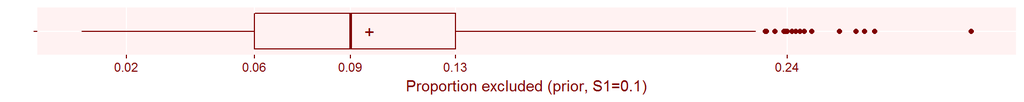

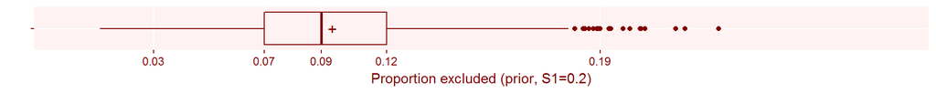

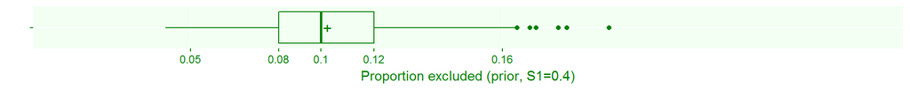

### Figure 7.2. Prior distribution for pi2, proportion refusing.

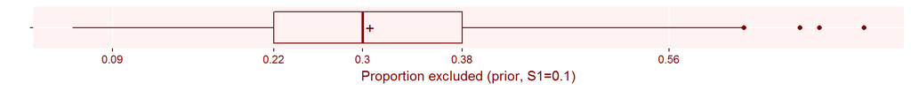

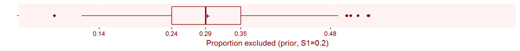

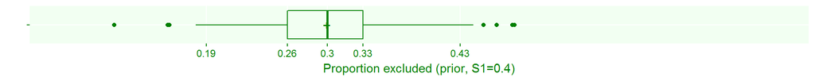

If you do a simple extrapolation, the total sample size after exclusions and refusals should be about 63% of the 350 planned patients or 220.5 patients.

### Here’s what the code would look like for this model.

```
## data {
##   int<lower=1>           N; // planned number of patients
##   real<lower=0>          T; // planned duration of trial
##   real<lower=0, upper=1> S; // strength of prior
##   int<lower=0>           n1; // observed patients
##   int<lower=0>           n2; // after exclusions
##   int<lower=0>           n3; // after exclusions and refusals
##   real<lower=0>          t; // observed time
##   real<lower=0, upper=1> P1; // planned proportion after exclusions
##   real<lower=0, upper=1> S1; // strength of prior for exclusion proportion
##   real<lower=0, upper=1> P2; // planned proportion after refusals
##   real<lower=0, upper=1> S2; // strength of prior for refusal proportion
##
## }
## parameters {
##   real<lower=0> lambda;
##   real<lower=0, upper=1> pi1;
##   real<lower=0, upper=1> pi2;
## }
## model {
##   lambda ~ gamma(N*S, T*S);
##   pi1 ~ beta(N*S1*P1, N*S1*(1-P1));
##   pi2 ~ beta(N*S2*P2, N*S2*(1-P2));
##   if (t>0) {
##     n1 ~ poisson(t*lambda);
##     n2 ~ binomial(n1, 1-pi1);
##     n3 ~ binomial(n2, 1-pi2);
##   }
## }
## generated quantities {
##   int<lower=0> N1star;
##   int<lower=0> N2star;
##   int<lower=0> N3star;
##   N1star = n1 + poisson_rng((T-t)*lambda);
##   N2star = n2 + binomial_rng(N1star-n1, 1-pi1);
##   N3star = n3 + binomial_rng(N2star-n2, 1-pi2);
## }
```

### Figure 7.3. Prior estimate of sample size, accounting for exclusions and refusals.

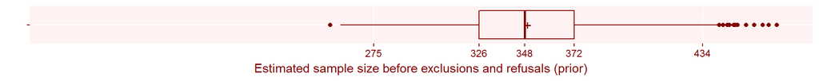

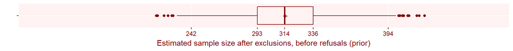

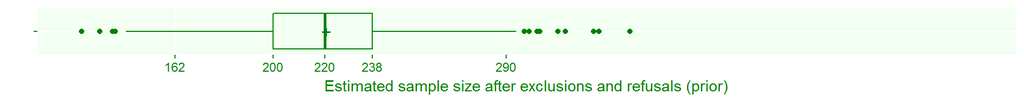

You should consider exploring how sensitive your estimated total sample size is relative to each of the binomial parameters.